# ManukaAnalysis

Melissa Taane

06/05/2019

#### F1 Layout

Map indicates the layout of the F1 generation resulting from a cross between EC201 and EC103 parents. Column 1 is approximately lengthways facing north.

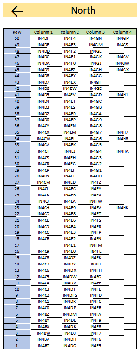

“Map of F1 Trees”

#### Height Diagram

Diagram indicates the areas of leaf collection regarding height. Each Tree had 10 leaves collected, 3 from Low, 4 from Mid and 3 from High. The first leaf sampled was measured twice for replication comparison.

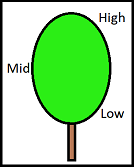

“Diagram of leaf collection levels”

#### Import and Arrange Data

“Full.xlsx” contains measurement information from sampling with the Dualex (https://www.force-a.com/en/capteurs-optiques-optical-sensors/dualex-scientific-chlorophyll-meter/), including;

- Surface content of chlorophyll in ?g/cm? (Chl)
- The index of epidermal flavanols (Flav)
- Nitrogen Balance Index status (NBI)
- Epidermal Anthocyanins (Anth).

It also contains information about the block position, the leaf height information, and presense or absence of flowering

Sheet “Dup” contains only the samples that were replicated.

```r
# Import Data Measures
Data <-read.xlsx("Full.xlsx", sheetName ="Full")
head(Data)
```

```
##   Collection.Day Allocation Block Column Row group Group.ID Tree.ID Rep.
## 1              4         CG     0      0   0    20       OG      CG    N
## 2              4         CG     0      0   0    20       OG      CG    N
## 3              4         CG     0      0   0    20       OG      CG    N
## 4              4         CG     0      0   0    20       OG      CG    N
## 5              4         CG     0      0   0    20       OG      CG    N
## 6              4         CG     0      0   0    20       OG      CG    N
##   measure Height Flower    Chl  Flav  Anth   NBI
## 1       9      H      Y 28.220 2.418 0.205 11.67
## 2       3      L      Y 27.958 2.298 0.691 12.17
## 3      11      H      Y 33.727 2.458 0.527 13.72
## 4       4      L      Y 25.938 1.758 0.172 14.76
## 5      10      H      Y 36.205 2.283 0.270 15.86
## 6       6      M      Y 34.332 2.115 0.150 16.23
```

```r
# Import Replicate Data
Dup <-read.xlsx("Full.xlsx", sheetName ="Dup")
head(Dup)
```

```
##   Collection.Day group Group.ID Tree.ID Rep. measure Height   Chl  Flav
## 1            2.0    23       60   IN4DV   Y1       1      L 1.916 2.363
## 2            1.5     3        1   IN4BT   Y1       1      L 3.124 2.300
## 3            2.0    17       54   IN4DL   Y2       2      L 3.414 1.826
## 4            1.5    32       28   IN4CP   Y2       2      L 4.097 1.943
## 5            2.0     9       46   IN4DC   Y1       1      L 4.909 1.928
## 6            1.5     5        3   IN4BW   Y1       1      L 4.924 1.848
##    Anth  NBI
## 1 0.174 0.81
## 2 0.191 1.36
## 3 0.112 1.87
## 4 0.051 2.11
## 5 0.103 2.55
## 6 0.165 2.66
```

```r
#Isolate Crimson Glory Outgroup
CG = Data[c(1:11),]
head(CG)
```

```
##   Collection.Day Allocation Block Column Row group Group.ID Tree.ID Rep.
## 1              4         CG     0      0   0    20       OG      CG    N
## 2              4         CG     0      0   0    20       OG      CG    N
## 3              4         CG     0      0   0    20       OG      CG    N
## 4              4         CG     0      0   0    20       OG      CG    N
## 5              4         CG     0      0   0    20       OG      CG    N
## 6              4         CG     0      0   0    20       OG      CG    N
##   measure Height Flower    Chl  Flav  Anth   NBI
## 1       9      H      Y 28.220 2.418 0.205 11.67
## 2       3      L      Y 27.958 2.298 0.691 12.17
## 3      11      H      Y 33.727 2.458 0.527 13.72
## 4       4      L      Y 25.938 1.758 0.172 14.76
## 5      10      H      Y 36.205 2.283 0.270 15.86
## 6       6      M      Y 34.332 2.115 0.150 16.23
```

```r
#Isolate East Cape 201 Parent
EC201 = Data[c(12:21),]
head(EC201)
```

```
##    Collection.Day Allocation Block Column Row group Group.ID Tree.ID Rep.
## 12              4      EC201     0      0   0    18       P1   EC201    N
## 13              4      EC201     0      0   0    18       P1   EC201    N
## 14              4      EC201     0      0   0    18       P1   EC201    N
## 15              4      EC201     0      0   0    18       P1   EC201    N
## 16              4      EC201     0      0   0    18       P1   EC201    N
## 17              4      EC201     0      0   0    18       P1   EC201    N
##    measure Height Flower    Chl  Flav  Anth   NBI
## 12       9      H      Y 30.722 2.138 0.156 14.37
## 13       6      M      Y 45.272 1.861 0.075 24.33
## 14      10      H      Y 46.174 1.868 0.052 24.72
## 15       8      M      Y 57.480 1.897 0.037 30.30
## 16       5      M      Y 57.752 1.681 0.125 34.35
## 17       3      L      Y 54.927 1.592 0.061 34.50
```

```r
#Isolate East Cape 103 Parent
EC103 = Data[c(22:33),]
head(EC103)
```

```
##    Collection.Day Allocation Block Column Row group Group.ID Tree.ID Rep.
## 22              4      EC103     0      0   0    19       P2   EC103    N
## 23              4      EC103     0      0   0    19       P2   EC103    N
## 24              4      EC103     0      0   0    19       P2   EC103    N
## 25              4      EC103     0      0   0    19       P2   EC103    N
## 26              4      EC103     0      0   0    19       P2   EC103    N
## 27              4      EC103     0      0   0    19       P2   EC103    N
##    measure Height Flower    Chl  Flav  Anth   NBI
## 22       8      M      Y 31.471 1.324 0.018 23.77
## 23      11      H      Y 57.349 2.111 0.053 27.17
## 24       4      L      Y 43.949 1.478 0.004 29.73
## 25      12      H      Y 56.779 1.846 0.108 30.75
## 26       9      M      Y 55.916 1.746 0.055 32.03
## 27      10      H      Y 57.809 1.746 0.054 33.11
```

```r
#Isolate Offspring from the Parental Cross
F1 = Data[c(34:1825),]
head(F1)
```

```
##    Collection.Day Allocation Block Column Row group Group.ID Tree.ID Rep.
## 34              1         F1     1      1   1    15        1   IN4BT    N
## 35              1         F1     1      1   1    15        1   IN4BT    N
## 36              1         F1     1      1   1    15        1   IN4BT    N
## 37              1         F1     1      1   1    15        1   IN4BT    N
## 38              1         F1     1      1   1    15        1   IN4BT    N
## 39              1         F1     1      1   1    15        1   IN4BT   Y1
##    measure Height Flower    Chl  Flav  Anth   NBI
## 34       8      M      N  3.268 1.958 0.143  1.67
## 35       2      L      N 23.326 2.581 0.065  9.04
## 36      11      M      N 24.682 2.265 0.112 10.90
## 37       7      M      N 27.068 2.229 0.084 12.14
## 38      14      H      N 27.459 2.135 0.138 12.86
## 39       3      L      N 34.592 2.583 0.048 13.39
```

#### Replicate Analysis

Replicates were taken by measuring a leaf sample of each tree twice, in order to establish consistency and reliability of measurements with the Dualex.

```r
#Anthocyanin Mean
AMR = mean(Dup$Anth);AMR
```

```
## [1] 0.09799367
```

```r
#Chlorophyll Mean
CMR = mean(Dup$Chl);CMR
```

```
## [1] 35.7627
```

```r
#Flavanoid Mean
FMR = mean(Dup$Flav);FMR
```

```
## [1] 1.967206
```

```r
#NBI Mean
NMR = mean(Dup$NBI);NMR
```

```
## [1] 18.73399
```

##### Replicate Plots

```r
#Boxplot Anthocyanin Replicates
RAnth <- ggplot(Dup) + aes(x = Rep., y = Anth) + geom_boxplot() +geom_hline(yintercept = AMR, color = "purple4") + ylab("Anthocyanin Content") + xlab("Leaf Replicate Number") + ggtitle("Anthocyanin Measurements of Two Replicate Groups") + theme_classic();plot +stat_boxplot(notch = TRUE)
```

```r
#Boxplot Chlorophyll Replicates
RChl<- ggplot(Dup) + aes(x = Rep., y = Chl) + geom_boxplot(colour = "darkorchid", fill = "plum") +geom_hline(yintercept = CMR, color = "darkorchid") + ylab("Chlorophyll g/cm") + xlab("Replicate Number") + ggtitle("Comparison of Chlorophyll levels of two replicate groups") + theme_classic();plot +stat_boxplot(notch = TRUE)
```

```r
#Boxplot Flavnol Replicates
RFlav <- ggplot(Dup) + aes(x = Rep., y = Flav) + geom_boxplot() +geom_hline(yintercept = FMR, color = "purple4") + ylab("Flavanold Content") + xlab("Leaf Replicate Number") + ggtitle("Flavonoid Measurements of Two Replicate Groups") + theme_classic();plot +stat_boxplot(notch = TRUE)
```

```r
#Boxplot NBI Replicates
RNBI <- ggplot(Dup) + aes(x = Rep., y = NBI) + geom_boxplot() +geom_hline(yintercept = NMR, color = "purple4") + ylab("Nitrogen Balance Index") + xlab("Leaf Replicate Number") + ggtitle("Nitrogen Balance Index of Two Replicate Groups") + theme_classic();plot +stat_boxplot(notch = TRUE)
```

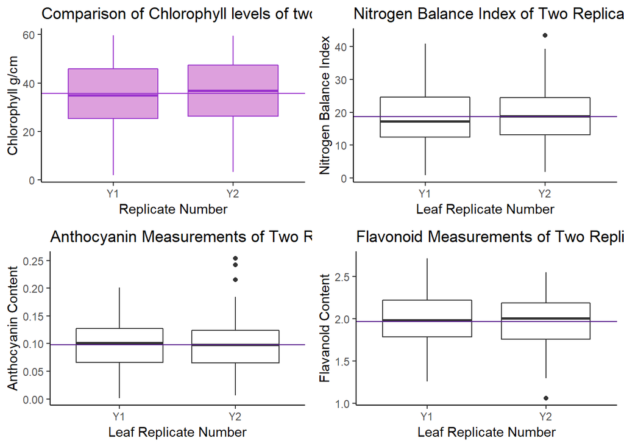

```r
#Display Boxplots
grid.arrange(RChl,RNBI,RAnth,RFlav, ncol = 2)
```

##### ANOVA of Replicates

```r
#Chlorophyll Anova
mod <-lm(Dup$Chl ~ Dup$Rep.)
anova(mod)
```

```
## Analysis of Variance Table
##
## Response: Dup$Chl
##            Df Sum Sq Mean Sq F value Pr(>F)
## Dup$Rep.    1    218  218.33   1.033 0.3102
## Residuals 314  66366  211.36
```

```r
#Flavanol Anova
mod2 <-lm(Dup$Flav ~ Dup$Rep.)
anova(mod2)
```

```
## Analysis of Variance Table
##
## Response: Dup$Flav
##            Df  Sum Sq  Mean Sq F value Pr(>F)
## Dup$Rep.    1  0.0521 0.052129  0.6506 0.4205
## Residuals 314 25.1596 0.080126
```

```r
#Anthocyanin Anova
mod3 <-lm(Dup$Anth ~ Dup$Rep.)
anova(mod3)
```

```
## Analysis of Variance Table
##
## Response: Dup$Anth
##            Df  Sum Sq   Mean Sq F value Pr(>F)
## Dup$Rep.    1 0.00003 0.0000304  0.0151 0.9023
## Residuals 314 0.63303 0.0020160
```

```r
#NBI Anova
mod4 <-lm(Dup$NBI ~ Dup$Rep.)
anova(mod4)
```

```
## Analysis of Variance Table
##
## Response: Dup$NBI
##            Df  Sum Sq Mean Sq F value Pr(>F)
## Dup$Rep.    1    82.5  82.530   1.115 0.2918
## Residuals 314 23241.0  74.016
```

The absence of statistically significant results indicates that our replicates are likely to be consistent.

#### Allocation Analysis

Allocation refers to which group measurements were taken from, i.e. A Parental Tree (EC103 or EC201), Outgroup Tree (CG), Parental Offspring (F1)

```r
#Anthocyanin Mean
AMA = mean(Data$Anth);AMA
```

```
## [1] 0.09772877
```

```r
#Chlorophyll Mean
CMA = mean(Data$Chl);CMA
```

```
## [1] 35.21443
```

```r
#Flavanol Mean
FMA = mean(Data$Flav);FMA
```

```
## [1] 1.964405
```

```r
#NBI Mean
NMA = mean(Data$NBI);NMA
```

```
## [1] 18.34807
```

#### Boxplot comparing medians and measurement distributions

```r
#Boxplot Anthocyanin Replicates
AAnth <- ggplot(Data) + aes(x = Allocation, y = Anth) + geom_boxplot() +geom_hline(yintercept = AMA, color = "purple4") + ylab("Anthocyanin Measure") + xlab("Allocation") + ggtitle("Anthocyanin of Tree Allocation") + theme_classic();plot +stat_boxplot(notch = TRUE)
```

```r
#Boxplot Chlorophyll Replicates
AChl <- ggplot(Data) + aes(x = Allocation, y = Chl) + geom_boxplot() +geom_hline(yintercept = CMA, color = "purple4") + ylab("Chlorophyll Measure") + xlab("Allocation") + ggtitle("Chlorophyll of Tree Allocation") + theme_classic();plot +stat_boxplot(notch = TRUE)
```

```r
#Boxplot Flavanol Replicates
AFlav <- ggplot(Data) + aes(x = Allocation, y = Flav) + geom_boxplot() +geom_hline(yintercept = FMA, color = "purple4") + ylab("Flavanol Measure") + xlab("Allocation") + ggtitle("Flavonol of Tree Allocation") + theme_classic();plot +stat_boxplot(notch = TRUE)
```

```r
#Boxplot NBI Replicates
ANBI <- ggplot(Data) + aes(x = Allocation, y = NBI) + geom_boxplot() +geom_hline(yintercept = NMA, color = "purple4") + ylab("NBI Measure") + xlab("Allocation") + ggtitle("NBI of Tree Allocation") + theme_classic();plot +stat_boxplot(notch = TRUE)
```

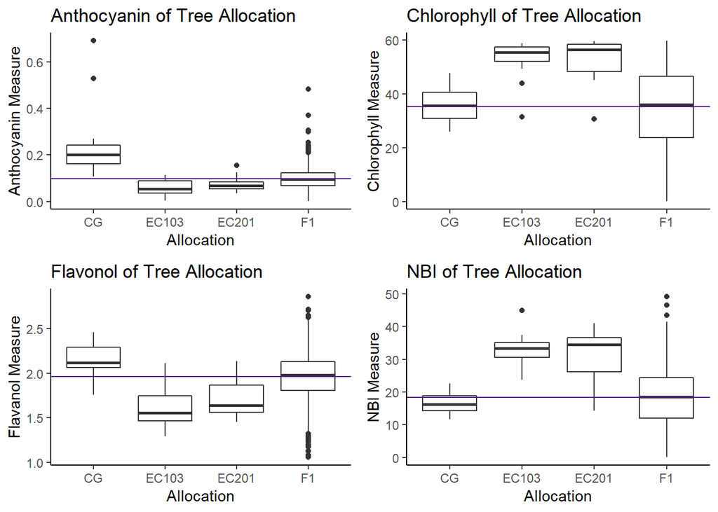

```r
#Display Plots
grid.arrange(AAnth,AChl,AFlav,ANBI, ncol=2)
```

##### ANOVAs

```r
#Chlorophyll
mod5 <-lm(Data$Chl ~ Data$Allocation)
anova(mod5)
```

```
## Analysis of Variance Table
##
## Response: Data$Chl
##                   Df Sum Sq Mean Sq F value    Pr(>F)
## Data$Allocation    3   6742 2247.21  9.9149 1.748e-06 ***
## Residuals       1821 412728  226.65
## ---
## Signif. codes:  0 '***' 0.001 '**' 0.01 '*' 0.05 '.' 0.1 ' ' 1
```

```r
#Nitrogen
mod6 <-lm(Data$NBI ~ Data$Allocation)
anova(mod5)
```

```
## Analysis of Variance Table
##
## Response: Data$Chl
##                   Df Sum Sq Mean Sq F value    Pr(>F)
## Data$Allocation    3   6742 2247.21  9.9149 1.748e-06 ***
## Residuals       1821 412728  226.65
## ---
## Signif. codes:  0 '***' 0.001 '**' 0.01 '*' 0.05 '.' 0.1 ' ' 1
```

```r
#Flavanol
mod7 <-lm(Data$Flav ~ Data$Allocation)
anova(mod7)
```

```
## Analysis of Variance Table
##
## Response: Data$Flav
##                   Df  Sum Sq Mean Sq F value    Pr(>F)
## Data$Allocation    3   2.713 0.90423  14.755 1.708e-09 ***
## Residuals       1821 111.598 0.06128
## ---
## Signif. codes:  0 '***' 0.001 '**' 0.01 '*' 0.05 '.' 0.1 ' ' 1
```

```r
#Anthocyanin
mod8 <-lm(Data$Anth ~ Data$Allocation)
anova(mod8)
```

```
## Analysis of Variance Table
##
## Response: Data$Anth
##                   Df Sum Sq  Mean Sq F value    Pr(>F)
## Data$Allocation    3 0.3040 0.101343  47.474 < 2.2e-16 ***
## Residuals       1821 3.8873 0.002135
## ---
## Signif. codes:  0 '***' 0.001 '**' 0.01 '*' 0.05 '.' 0.1 ' ' 1
```

#### Parent Tree Analysis

```r
#Binding parents into single dataset
Parent <- rbind(EC201,EC103)

#Anthocyanin Mean
AMP = mean(Parent$Anth)
#Anthocyanin Boxplot
PAnth <- ggplot(Parent) + aes(x = Tree.ID, y = Anth) + geom_boxplot() +geom_hline(yintercept = AMP, color = "purple4") + ylab("Anthocyanin Measure") + xlab("Tree ID") + ggtitle("Anthocyanin of Parent Trees") + theme_classic();plot +stat_boxplot(notch = TRUE)
```

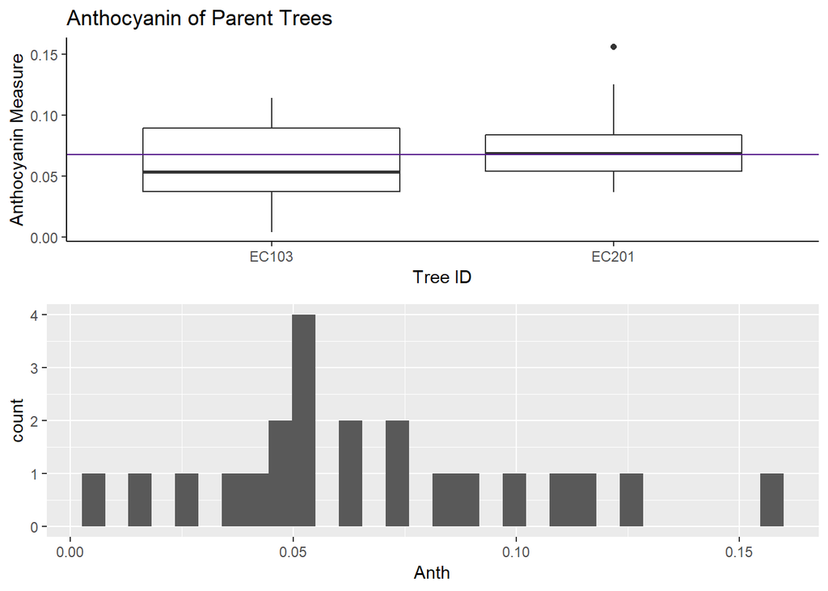

```r
#Anthocyanin histogram
PHAnth <- ggplot(Parent) + aes(x = Anth) + geom_histogram()
#Anthocyanin Display plots
grid.arrange(PAnth, PHAnth)
```

```r
#Anthocyanin T.test
t.test(Parent$Anth ~ Parent$Tree.ID)
```

```
##
##  Welch Two Sample t-test
##
## data:  Parent$Anth by Parent$Tree.ID
## t = -1.2283, df = 19.107, p-value = 0.2342
## alternative hypothesis: true difference in means is not equal to 0
## 95 percent confidence interval:
##  -0.05154327  0.01340994
## sample estimates:
## mean in group EC103 mean in group EC201
##          0.05883333          0.07790000
```

```r
#Chlorophyll Mean
CMP = mean(Parent$Chl)
#Chlorophyll Boxplot
PChl <- ggplot(Parent) + aes(x = Tree.ID, y = Chl) + geom_boxplot() +geom_hline(yintercept = CMP, color = "purple4") + ylab("Chlorophyll Measure") + xlab("Tree ID") + ggtitle("Chlorophyll of Parent Trees") + theme_classic();plot +stat_boxplot(notch = TRUE)
```

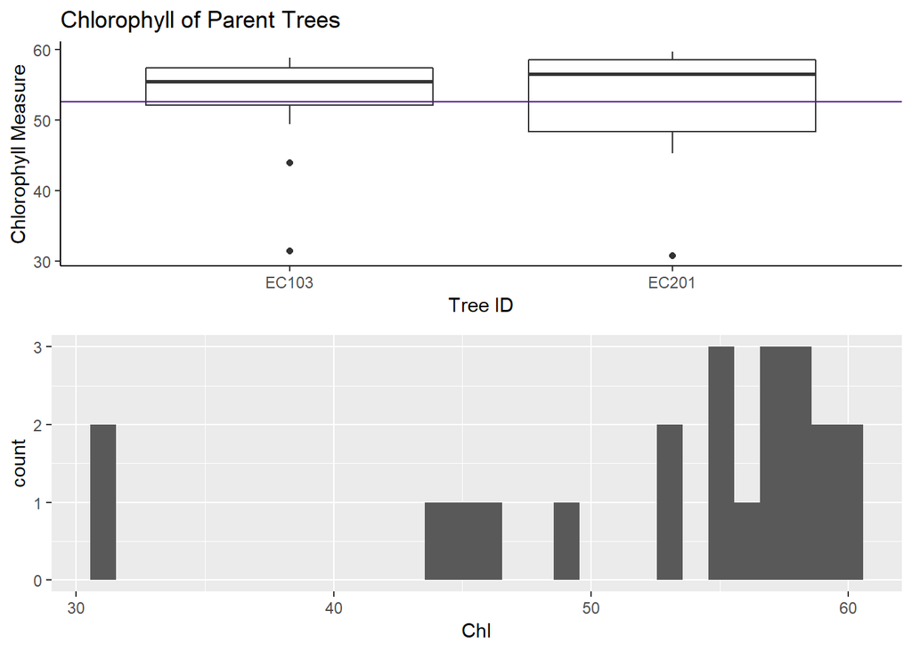

```r
#Chlorophyll histogram
PHChl <- ggplot(Parent) + aes(x = Chl) + geom_histogram()
#Anthocyanin Display plots
grid.arrange(PChl, PHChl)
```

```r
#Anthocyanin T.test
t.test(Parent$Chl ~ Parent$Tree.ID)
```

```
##
##  Welch Two Sample t-test
##
## data:  Parent$Chl by Parent$Tree.ID
## t = -0.003842, df = 17.804, p-value = 0.997
## alternative hypothesis: true difference in means is not equal to 0
## 95 percent confidence interval:
##  -7.830954  7.802387
## sample estimates:
## mean in group EC103 mean in group EC201
##            52.59242            52.60670
```

```r
#Flavonol Mean
FMP = mean(Parent$Flav)
#Anthocyanin Boxplot
PFlav <- ggplot(Parent) + aes(x = Tree.ID, y = Flav) + geom_boxplot() +geom_hline(yintercept = FMP, color = "purple4") + ylab("Flavanol Measure") + xlab("Tree ID") + ggtitle("Flavonol of Parent Trees") + theme_classic();plot +stat_boxplot(notch = TRUE)
```

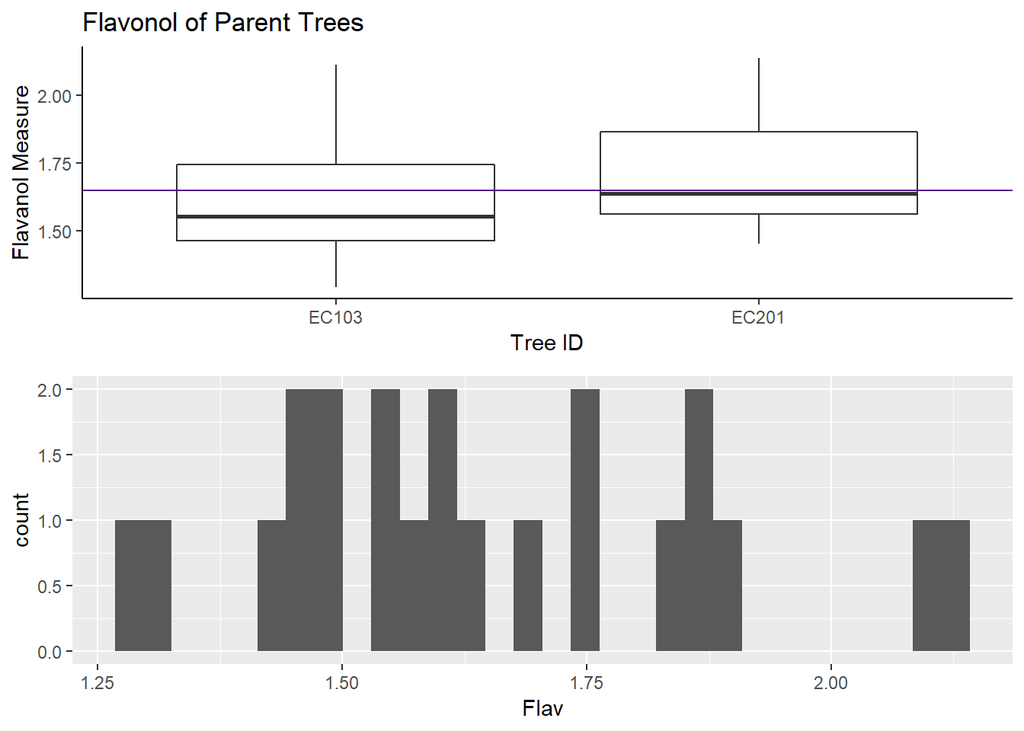

```r
#Anthocyanin histogram
PHFlav <- ggplot(Parent) + aes(x = Flav) + geom_histogram()
#Anthocyanin Display plots
grid.arrange(PFlav, PHFlav)
```

```r
#Anthocyanin T.test
t.test(Parent$Flav ~ Parent$Tree.ID)
```

```
##
##  Welch Two Sample t-test
##
## data:  Parent$Flav by Parent$Tree.ID
## t = -1.141, df = 19.612, p-value = 0.2676
## alternative hypothesis: true difference in means is not equal to 0
## 95 percent confidence interval:
##  -0.31409194  0.09215861
## sample estimates:
## mean in group EC103 mean in group EC201
##            1.599833            1.710800
```

```r
#NBI Mean
NMP = mean(Parent$NBI)
#NBI Boxplot
PNBI <- ggplot(Parent) + aes(x = Tree.ID, y = NBI) + geom_boxplot() +geom_hline(yintercept = NMP, color = "purple4") + ylab("NBI Measure") + xlab("Tree ID") + ggtitle("Anthocyanin of Parent Trees") + theme_classic();plot +stat_boxplot(notch = TRUE)
```

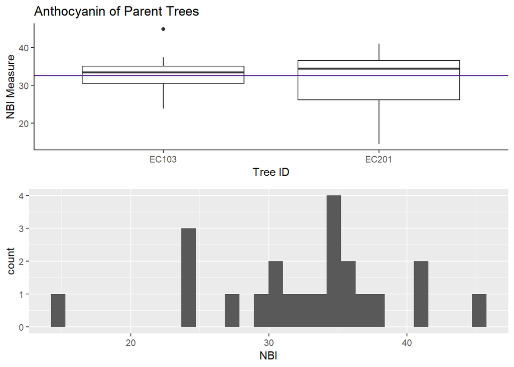

```r
#NBI histogram
PHNBI <- ggplot(Parent) + aes(x = NBI) + geom_histogram()
#Anthocyanin Display plots
grid.arrange(PNBI, PHNBI)
```

```r
#Anthocyanin T.test
t.test(Parent$NBI ~ Parent$Tree.ID)
```

```
##
##  Welch Two Sample t-test
##
## data:  Parent$NBI by Parent$Tree.ID
## t = 0.47573, df = 14.7, p-value = 0.6413
## alternative hypothesis: true difference in means is not equal to 0
## 95 percent confidence interval:
##  -5.076667  7.987334
## sample estimates:
## mean in group EC103 mean in group EC201
##            33.14333            31.68800
```

#### Parental Cross Analysis (F1 Generation)

Investigating measures across the F1 cross population

```r
#Grouping F1 Measures By Tree
F12 <-group_by(F1,Tree.ID)
F12 <- summarise(F12,Chl = mean(Chl,na.rm=T), NBI = mean(NBI, ra.nm = T), Anth = mean(Anth, na.rm=T),Flav = mean(Flav,na.rm =T))
View(F12)
#Anthocyanin Mean
AMF = mean(F12$Anth);AMF
```

```
## [1] 0.09699261
```

```r
#Chlorophyll Mean
CMF = mean(F12$Chl);CMF
```

```
## [1] 35.13564
```

```r
#Flavanol Mean
FMF = mean(F12$Flav);FMF
```

```
## [1] 1.965265
```

```r
#NBI Mean
NMF = mean(F12$NBI); NMF
```

```
## [1] 18.27171
```

```r
#Boxplot Anthocyanin F1
FAnth <- ggplot(F1) + aes(x = Tree.ID, y = Anth) + geom_boxplot() +geom_hline(yintercept = AMF, color = "purple4") + ylab("Anthocyanin Measure") + xlab("Tree ID") + ggtitle("Anthocyanin of F1 population") + theme_classic();plot +stat_boxplot(notch = TRUE)
```

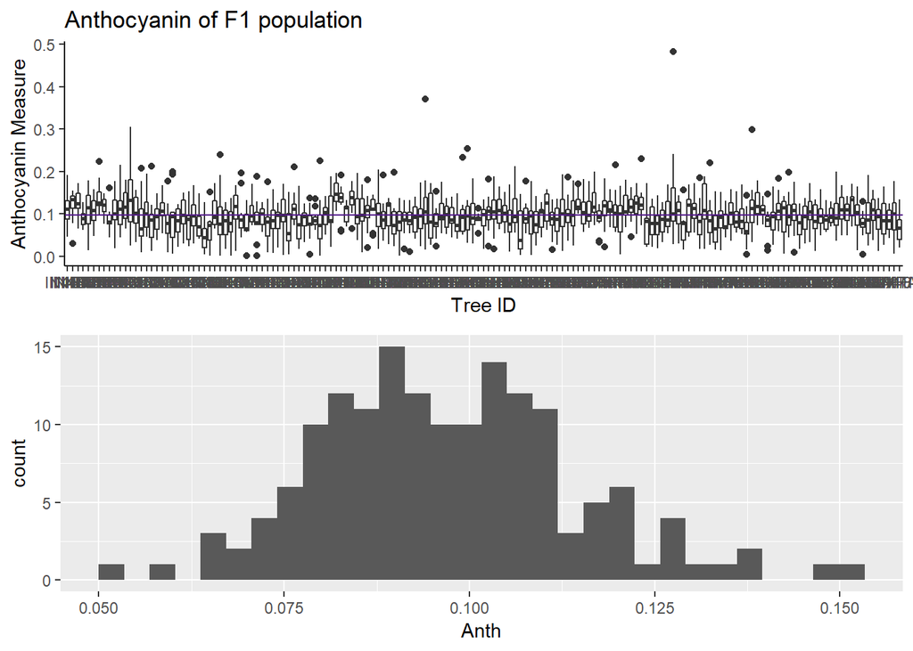

```r
#Histogram of Anthocyanin Distribution
FHAnth <- ggplot(F12) + aes(x = Anth) + geom_histogram()
#Display Anthocyanin Plots
grid.arrange(FAnth,FHAnth)
```

```r
#Anthocyanin ANOVA
FAA = lm(F1$Anth ~ F1$Tree.ID)
anova(FAA)
```

```
## Analysis of Variance Table
##
## Response: F1$Anth
##              Df Sum Sq   Mean Sq F value    Pr(>F)
## F1$Tree.ID  158 0.5253 0.0033247  1.8093 2.001e-08 ***
## Residuals  1633 3.0007 0.0018376
## ---
## Signif. codes:  0 '***' 0.001 '**' 0.01 '*' 0.05 '.' 0.1 ' ' 1
```

```r
#Boxplot Chlorophyll F1
FChl <- ggplot(F1) + aes(x = Tree.ID, y = Chl) + geom_boxplot() +geom_hline(yintercept = CMF, color = "purple4") + ylab("Chlorophyll Measure") + xlab("Tree ID") + ggtitle("Chlorophyll of F1 Population") + theme_classic();plot +stat_boxplot(notch = TRUE)
```

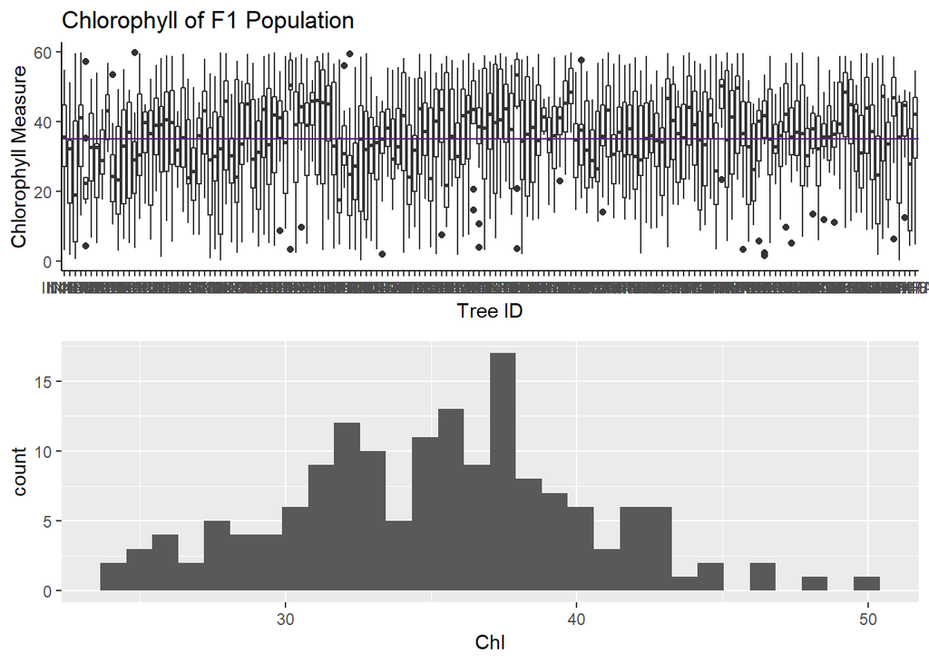

```r
#Histogram of Chlorophyll
FHChl <- ggplot(F12) + aes(x = Chl) + geom_histogram()
#Display Chlorophyll Plots
grid.arrange(FChl, FHChl)
```

```r
#Chlorophyll ANOVA
FCA = lm(F1$Chl ~ F1$Tree.ID)
anova(FCA)
```

```
## Analysis of Variance Table
##
## Response: F1$Chl
##              Df Sum Sq Mean Sq F value   Pr(>F)
## F1$Tree.ID  158  47130  298.29  1.3395 0.004474 **
## Residuals  1633 363634  222.68
## ---
## Signif. codes:  0 '***' 0.001 '**' 0.01 '*' 0.05 '.' 0.1 ' ' 1
```

```r
#Boxplot Flavanol F1
FFlav <- ggplot(F1) + aes(x = Tree.ID, y = Flav) + geom_boxplot() +geom_hline(yintercept = FMF, color = "purple4") + ylab("Flavanol Measure") + xlab("Tree ID") + ggtitle("Flavonol of F1 Population") + theme_classic();plot +stat_boxplot(notch = TRUE)
```

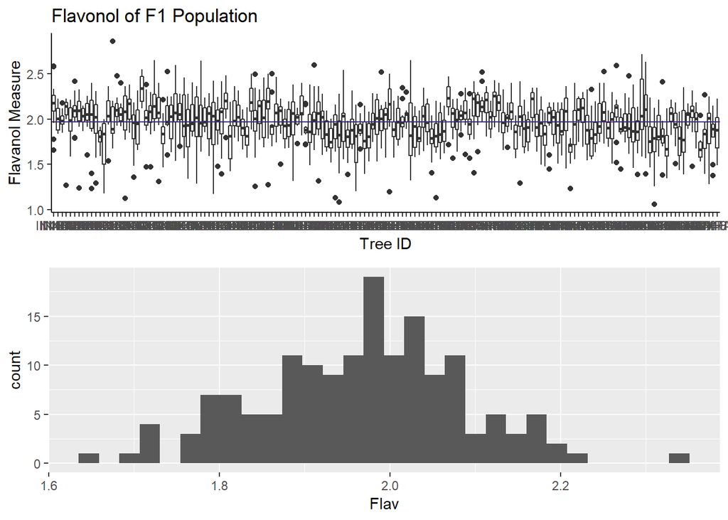

```r
#Histogram of Flavonol
FHFlav <- ggplot(F12) + aes(x = Flav) + geom_histogram()
#Display Chlorophyll Plots
grid.arrange(FFlav, FHFlav)
```

```r
#Flavonol ANOVA
FFA = lm(F1$Flav ~ F1$Tree.ID)
anova(FFA)
```

```
## Analysis of Variance Table
##
## Response: F1$Flav
##              Df Sum Sq Mean Sq F value    Pr(>F)
## F1$Tree.ID  158 25.118 0.15897  3.0531 < 2.2e-16 ***
## Residuals  1633 85.030 0.05207
## ---
## Signif. codes:  0 '***' 0.001 '**' 0.01 '*' 0.05 '.' 0.1 ' ' 1
```

```r
#Boxplot NBI F1
FNBI <- ggplot(F1) + aes(x = Tree.ID, y = NBI) + geom_boxplot() +geom_hline(yintercept = NMF, color = "purple4") + ylab("NBI Measure") + xlab("Tree ID") + ggtitle("NBI of F1 Population") + theme_classic();plot +stat_boxplot(notch = TRUE)
```

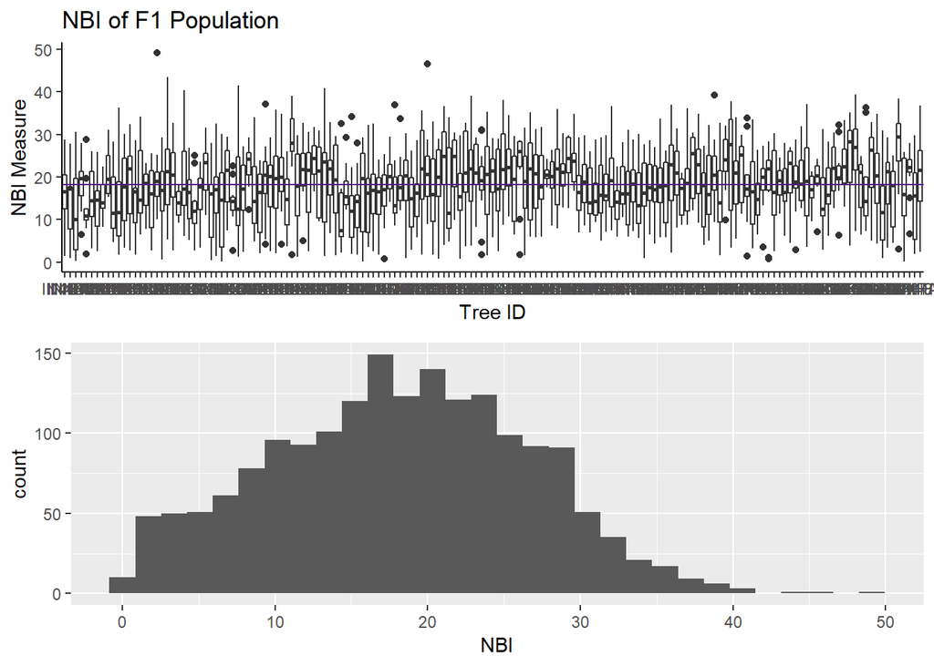

```r
#Histogram of NBI
FHNBI <- ggplot(F1) + aes(x = NBI) + geom_histogram()
#Display NBI Plots
grid.arrange(FNBI, FHNBI)
```

```r
#NBI ANOVA
FNA = lm(F1$NBI ~ F1$Tree.ID)
anova(FNA)
```

```
## Analysis of Variance Table
##
## Response: F1$NBI
##              Df Sum Sq Mean Sq F value    Pr(>F)
## F1$Tree.ID  158  16378 103.661  1.5147 8.435e-05 ***
## Residuals  1633 111761  68.439
## ---
## Signif. codes:  0 '***' 0.001 '**' 0.01 '*' 0.05 '.' 0.1 ' ' 1
```

#### Height Analysis

```r
#Boxplot Anthocyanin Height
HAnth <- ggplot(F1) + aes(x = Height, y = Anth) + geom_boxplot() +geom_hline(yintercept = AMF, color = "purple4") + ylab("Anthocyanin Measure") + xlab("Height") + ggtitle("Anthocyanin of F1 population by Height") + theme_classic();plot +stat_boxplot(notch = TRUE)
```

```r
#Boxplot Chlorophyll F1
HChl <- ggplot(F1) + aes(x = Height, y = Chl) + geom_boxplot() +geom_hline(yintercept = CMF, color = "purple4") + ylab("Chlorophyll Measure") + xlab("Height") + ggtitle("Chlorophyll of F1 Population") + theme_classic();plot +stat_boxplot(notch = TRUE)
```

```r
#Boxplot Flavanol F1
HFlav <- ggplot(F1) + aes(x = Height, y = Flav) + geom_boxplot() +geom_hline(yintercept = FMF, color = "purple4") + ylab("Flavanol Measure") + xlab("Height") + ggtitle("Flavonol of F1 Population by Height") + theme_classic();plot +stat_boxplot(notch = TRUE)
```

```r
#Boxplot NBI F1
HNBI <- ggplot(F1) + aes(x = Height, y = NBI) + geom_boxplot() +geom_hline(yintercept = NMF, color = "purple4") + ylab("NBI Measure") + xlab("Height") + ggtitle("NBI of F1 Population") + theme_classic();plot +stat_boxplot(notch = TRUE)
```

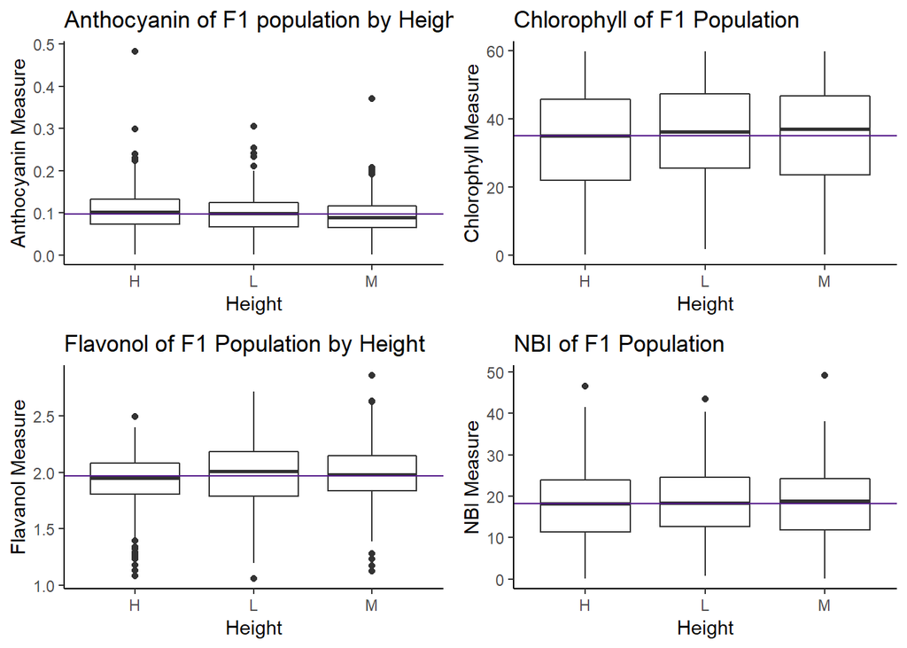

```r
grid.arrange(HAnth,HChl,HFlav,HNBI)
```

```r
#Anthocyanin ANOVA
HAA = lm(F1$Anth ~ F1$Height)
anova(HAA)
```

```
## Analysis of Variance Table
##
## Response: F1$Anth
##             Df Sum Sq   Mean Sq F value    Pr(>F)
## F1$Height    2 0.0526 0.0262759  13.533 1.468e-06 ***
## Residuals 1789 3.4735 0.0019416
## ---
## Signif. codes:  0 '***' 0.001 '**' 0.01 '*' 0.05 '.' 0.1 ' ' 1
```

```r
#Chlorophyll ANOVA
HCA = lm(F1$Chl ~ F1$Height)
anova(FCA)
```

```
## Analysis of Variance Table
##
## Response: F1$Chl
##              Df Sum Sq Mean Sq F value   Pr(>F)
## F1$Tree.ID  158  47130  298.29  1.3395 0.004474 **
## Residuals  1633 363634  222.68
## ---
## Signif. codes:  0 '***' 0.001 '**' 0.01 '*' 0.05 '.' 0.1 ' ' 1
```

```r
#Flavonol ANOVA
HFA = lm(F1$Flav ~ F1$Height)
anova(HFA)
```

```
## Analysis of Variance Table
##
## Response: F1$Flav
##             Df  Sum Sq Mean Sq F value    Pr(>F)
## F1$Height    2   0.915 0.45758  7.4943 0.0005739 ***
## Residuals 1789 109.232 0.06106
## ---
## Signif. codes:  0 '***' 0.001 '**' 0.01 '*' 0.05 '.' 0.1 ' ' 1
```

```r
#NBI ANOVA
HNA = lm(F1$NBI ~ F1$Height)
anova(HNA)
```

```
## Analysis of Variance Table
##
## Response: F1$NBI
##             Df Sum Sq Mean Sq F value Pr(>F)
## F1$Height    2    100  50.044  0.6992 0.4971
## Residuals 1789 128039  71.570
```

#### Row Analysis

```r
#Grouping data by ROw
F1R = group_by(F1,Row)
F1R = summarise(F1R,Chl = mean(Chl,na.rm=T), NBI = mean(NBI, ra.nm = T), Anth = mean(Anth, na.rm=T),Flav = mean(Flav,na.rm =T))


#Boxplot Anthocyanin Height
RoAnth <- ggplot(F1) + aes(x = Row, y = Anth) + geom_boxplot() +geom_hline(yintercept = AMF, color = "purple4") + ylab("Anthocyanin Measure") + xlab("Row") + ggtitle("Anthocyanin of F1 population by Row") + theme_classic();plot +stat_boxplot(notch = TRUE)
```

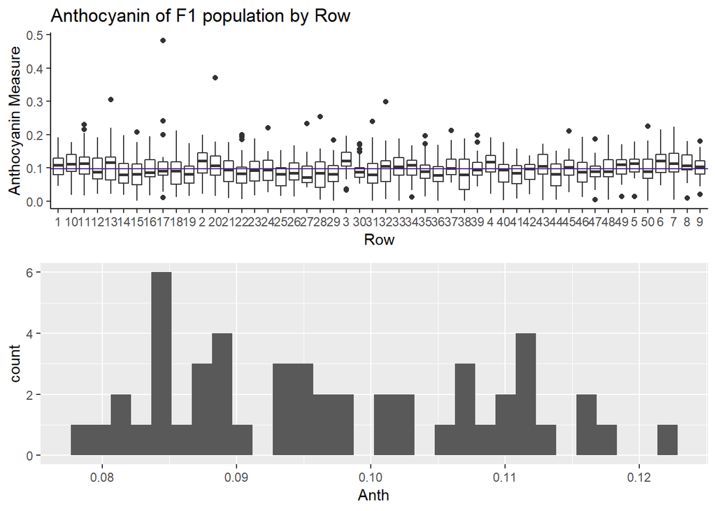

```r
#Histogram of Anthocyanin
RoHAnth <- ggplot(F1R) + aes(x = Anth) + geom_histogram()
#Display plots
grid.arrange(RoAnth,RoHAnth)
```

```r
#Anthocyanin ANOVA
RoAA = lm(F1$Anth ~ F1$Row)
anova(RoAA)
```

```
## Analysis of Variance Table
##
## Response: F1$Anth
##             Df Sum Sq   Mean Sq F value    Pr(>F)
## F1$Row      49 0.2346 0.0047878  2.5339 4.261e-08 ***
## Residuals 1742 3.2914 0.0018895
## ---
## Signif. codes:  0 '***' 0.001 '**' 0.01 '*' 0.05 '.' 0.1 ' ' 1
```

```r
#Boxplot Chlorophyll F1
RoChl <- ggplot(F1) + aes(x = Row, y = Chl) + geom_boxplot() +geom_hline(yintercept = CMF, color = "purple4") + ylab("Chlorophyll Measure") + xlab("Row") + ggtitle("Chlorophyll of F1 Population by Row") + theme_classic();plot +stat_boxplot(notch = TRUE)
```

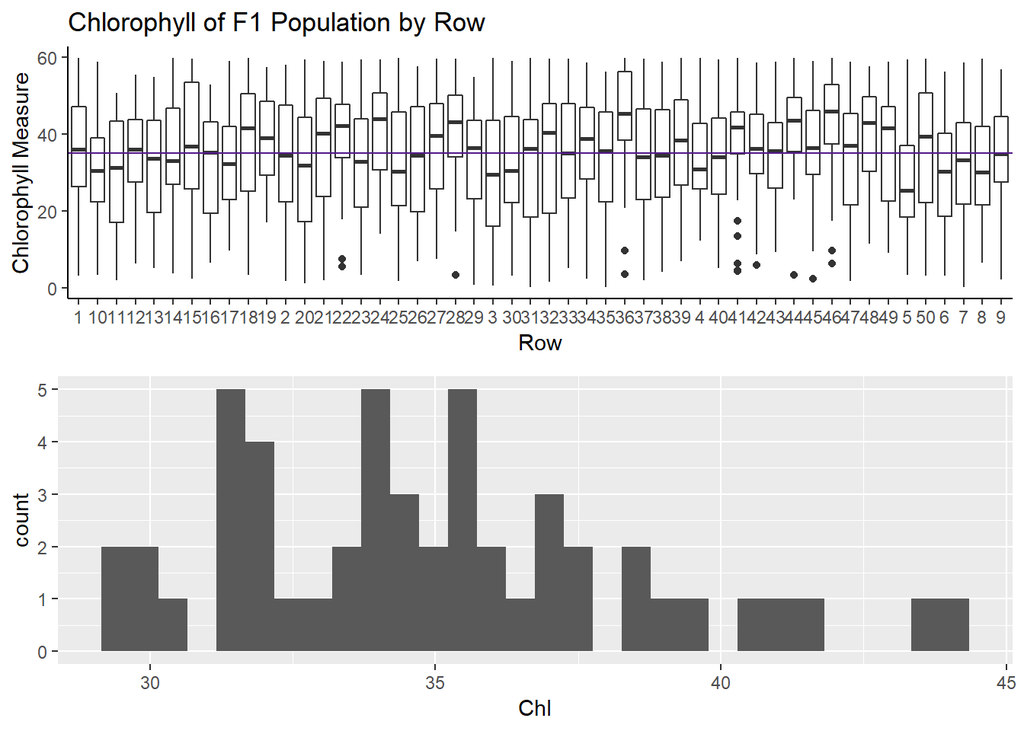

```r
#Histogram of Chlorophyll
RoHChl <- ggplot(F1R) + aes(x = Chl) + geom_histogram()
#Display plots
grid.arrange(RoChl,RoHChl)
```

```r
#Anthocyanin ANOVA
RoCA = lm(F1$Chl ~ F1$Row)
anova(RoCA)
```

```
## Analysis of Variance Table
##
## Response: F1$Chl
##             Df Sum Sq Mean Sq F value    Pr(>F)
## F1$Row      49  21394  436.61  1.9533 0.0001046 ***
## Residuals 1742 389370  223.52
## ---
## Signif. codes:  0 '***' 0.001 '**' 0.01 '*' 0.05 '.' 0.1 ' ' 1
```

```r
#Boxplot Flavanol F1
RoFlav <- ggplot(F1) + aes(x = Row, y = Flav) + geom_boxplot() +geom_hline(yintercept = FMF, color = "purple4") + ylab("Flavanol Measure") + xlab("Row") + ggtitle("Flavonol of F1 Population by Row") + theme_classic();plot +stat_boxplot(notch = TRUE)
```

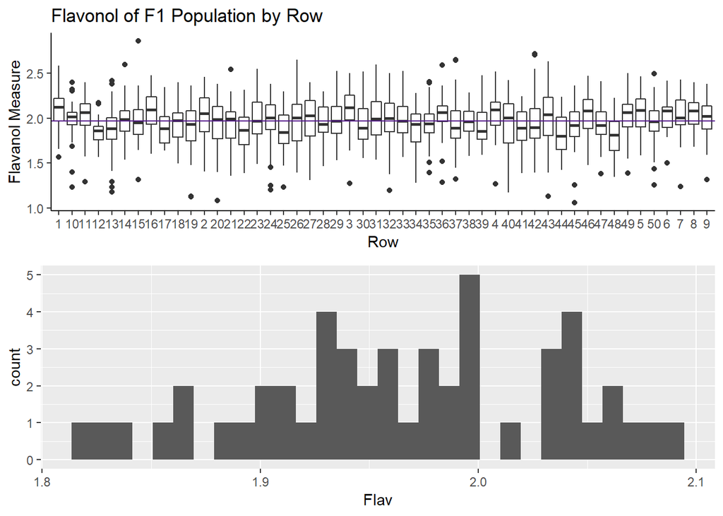

```r
#Histogram of Flavonol
RoHFlav <- ggplot(F1R) + aes(x = Flav) + geom_histogram()
#Display plots
grid.arrange(RoFlav,RoHFlav)
```

```r
#Anthocyanin ANOVA
RoFA = lm(F1$Flav ~ F1$Row)
anova(RoFA)
```

```
## Analysis of Variance Table
##
## Response: F1$Flav
##             Df  Sum Sq  Mean Sq F value   Pr(>F)
## F1$Row      49   8.215 0.167646   2.865 3.11e-10 ***
## Residuals 1742 101.933 0.058515
## ---
## Signif. codes:  0 '***' 0.001 '**' 0.01 '*' 0.05 '.' 0.1 ' ' 1
```

```r
#Boxplot NBI F1
RoNBI <- ggplot(F1) + aes(x = Row, y = NBI) + geom_boxplot() +geom_hline(yintercept = NMF, color = "purple4") + ylab("NBI Measure") + xlab("Row") + ggtitle("NBI of F1 Population by Row") + theme_classic();plot +stat_boxplot(notch = TRUE)
```

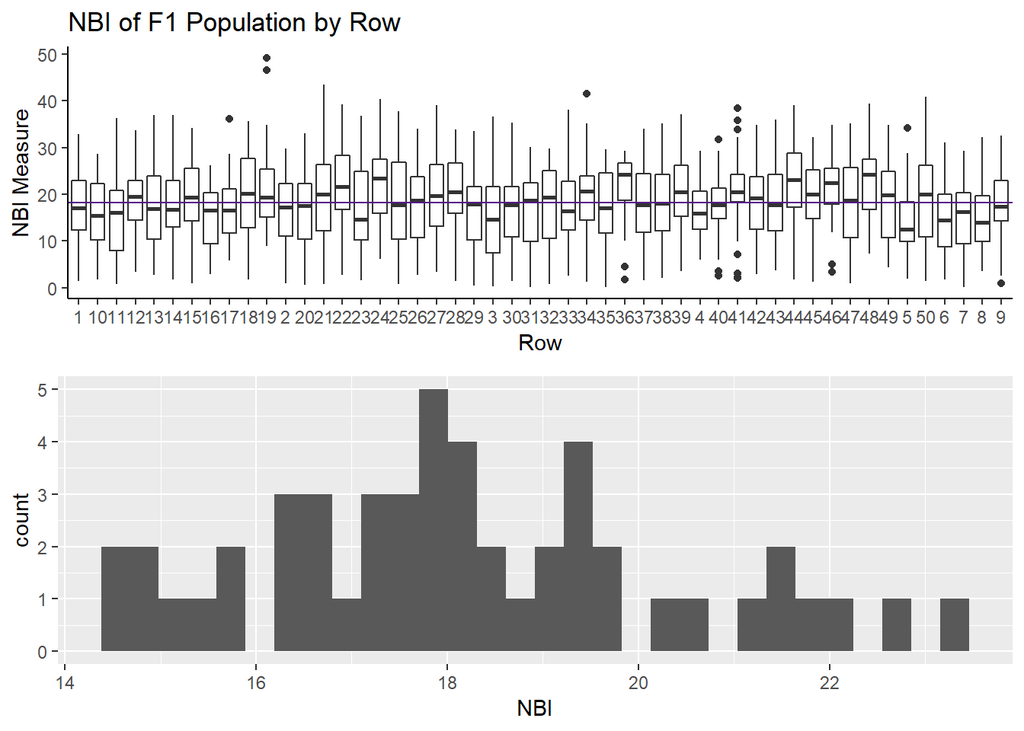

```r
#Histogram of NBI
RoHNBI <- ggplot(F1R) + aes(x = NBI) + geom_histogram()
#Display plots
grid.arrange(RoNBI,RoHNBI)
```

```r
#Anthocyanin ANOVA
RoNA = lm(F1$NBI ~ F1$Row)
anova(RoNA)
```

```
## Analysis of Variance Table
##
## Response: F1$NBI
##             Df Sum Sq Mean Sq F value   Pr(>F)
## F1$Row      49   7866 160.527   2.325 8.14e-07 ***
## Residuals 1742 120273  69.043
## ---
## Signif. codes:  0 '***' 0.001 '**' 0.01 '*' 0.05 '.' 0.1 ' ' 1
```

#### Column Analysis

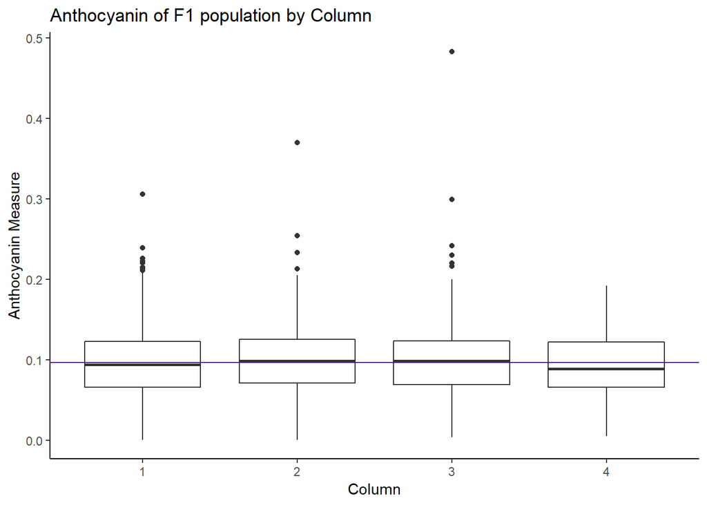

```r
#Making Column Values Factors
F1$Column = as.factor(F1$Column)
#Grouping data by Column
F1C = group_by(F1,Column)
F1C = summarise(F1R,Chl = mean(Chl,na.rm=T), NBI = mean(NBI, ra.nm = T), Anth = mean(Anth, na.rm=T),Flav = mean(Flav,na.rm =T))

#Boxplot Anthocyanin Height
CAnth <- ggplot(F1) + aes(x = Column, y = Anth) + geom_boxplot() +geom_hline(yintercept = AMF, color = "purple4") + ylab("Anthocyanin Measure") + xlab("Column") + ggtitle("Anthocyanin of F1 population by Column") + theme_classic();plot +stat_boxplot(notch = TRUE);CAnth
```

```r
#Anthocyanin ANOVA
CAA = lm(F1$Anth ~ F1$Column)
anova(CAA)
```

```
## Analysis of Variance Table
##
## Response: F1$Anth
##             Df Sum Sq   Mean Sq F value Pr(>F)
## F1$Column    3 0.0122 0.0040655  2.0687 0.1024
## Residuals 1788 3.5138 0.0019652
```

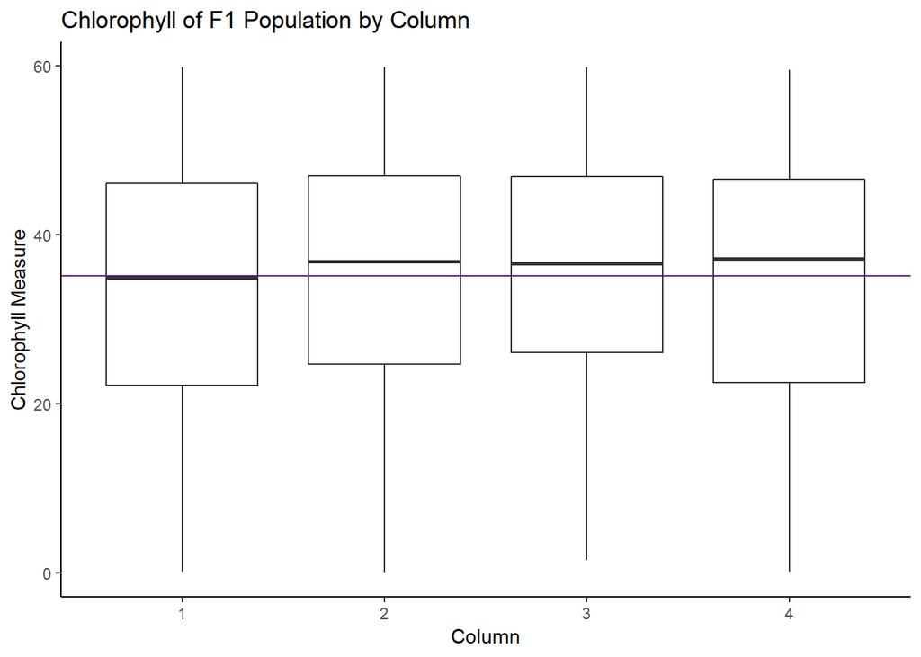

```r
#Boxplot Chlorophyll F1
CChl <- ggplot(F1) + aes(x = Column, y = Chl) + geom_boxplot() +geom_hline(yintercept = CMF, color = "purple4") + ylab("Chlorophyll Measure") + xlab("Column") + ggtitle("Chlorophyll of F1 Population by Column") + theme_classic();plot +stat_boxplot(notch = TRUE);CChl
```

```r
#Anthocyanin ANOVA
CCA = lm(F1$Chl ~ F1$Column)
anova(CCA)
```

```
## Analysis of Variance Table
##
## Response: F1$Chl
##             Df Sum Sq Mean Sq F value  Pr(>F)
## F1$Column    3   1586  528.66  2.3101 0.07453 .
## Residuals 1788 409178  228.85
## ---
## Signif. codes:  0 '***' 0.001 '**' 0.01 '*' 0.05 '.' 0.1 ' ' 1
```

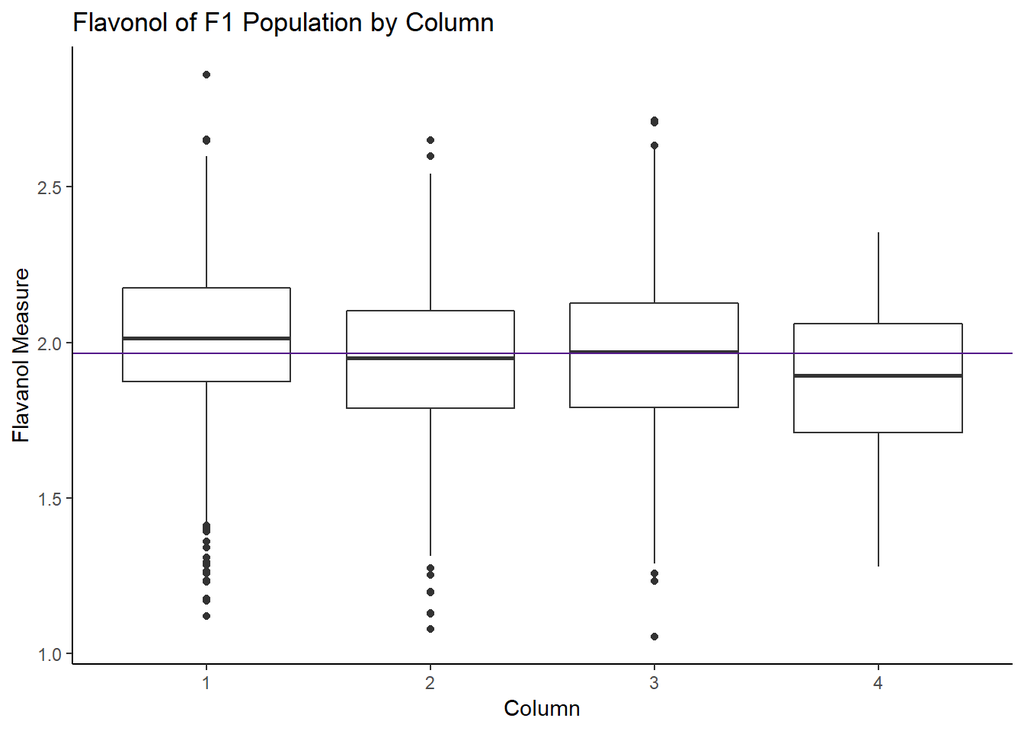

```r
#Boxplot Flavanol F1
CFlav <- ggplot(F1) + aes(x = Column, y = Flav) + geom_boxplot() +geom_hline(yintercept = FMF, color = "purple4") + ylab("Flavanol Measure") + xlab("Column") + ggtitle("Flavonol of F1 Population by Column") + theme_classic();plot +stat_boxplot(notch = TRUE);CFlav
```

```r
#Anthocyanin ANOVA
CFA = lm(F1$Flav ~ F1$Column)
anova(CFA)
```

```
## Analysis of Variance Table
##
## Response: F1$Flav
##             Df  Sum Sq Mean Sq F value    Pr(>F)
## F1$Column    3   2.305 0.76823  12.737 3.087e-08 ***
## Residuals 1788 107.843 0.06031
## ---
## Signif. codes:  0 '***' 0.001 '**' 0.01 '*' 0.05 '.' 0.1 ' ' 1
```

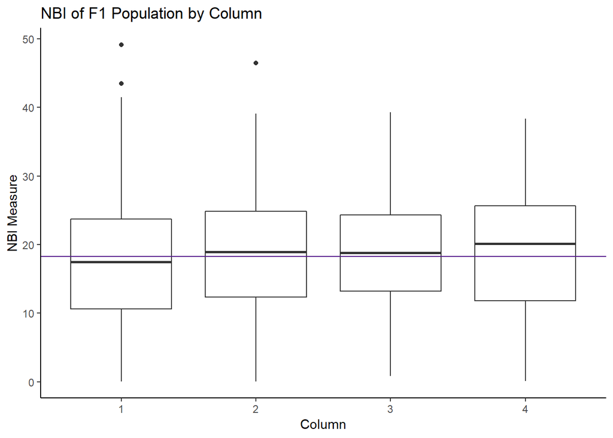

```r
#Boxplot NBI F1
CNBI <- ggplot(F1) + aes(x = Column, y = NBI) + geom_boxplot() +geom_hline(yintercept = NMF, color = "purple4") + ylab("NBI Measure") + xlab("Column") + ggtitle("NBI of F1 Population by Column") + theme_classic();plot +stat_boxplot(notch = TRUE);CNBI
```

```r
#Anthocyanin ANOVA
CNA = lm(F1$NBI ~ F1$Column)
anova(CNA)
```

```
## Analysis of Variance Table
##
## Response: F1$NBI
##             Df Sum Sq Mean Sq F value   Pr(>F)
## F1$Column    3    821 273.626  3.8427 0.009333 **
## Residuals 1788 127318  71.207
## ---
## Signif. codes:  0 '***' 0.001 '**' 0.01 '*' 0.05 '.' 0.1 ' ' 1
```

```r
#Anthocyanin
CRHA = lm(F1$Anth ~ F1$Height*F1$Column*F1$Row)
anova(CRHA)
```

```
## Analysis of Variance Table
##
## Response: F1$Anth
##                              Df  Sum Sq   Mean Sq F value    Pr(>F)
## F1$Height                     2 0.05255 0.0262759 14.9537 3.788e-07 ***
## F1$Column                     3 0.01228 0.0040942  2.3300 0.0727244 .
## F1$Row                       49 0.23127 0.0047199  2.6861 6.175e-09 ***
## F1$Height:F1$Column           6 0.02055 0.0034247  1.9490 0.0699958 .
## F1$Height:F1$Row             98 0.20024 0.0020433  1.1628 0.1394606
## F1$Column:F1$Row            106 0.28473 0.0026861  1.5287 0.0006952 ***
## F1$Height:F1$Column:F1$Row  212 0.41375 0.0019517  1.1107 0.1490621
## Residuals                  1315 2.31066 0.0017572
## ---
## Signif. codes:  0 '***' 0.001 '**' 0.01 '*' 0.05 '.' 0.1 ' ' 1
```

```r
#Remove insignificant variables
CRHA2 = lm(F1$Anth ~ F1$Height*F1$Row)
anova(CRHA2)
```

```
## Analysis of Variance Table
##
## Response: F1$Anth
##                    Df  Sum Sq   Mean Sq F value    Pr(>F)
## F1$Height           2 0.05255 0.0262759 14.2135 7.586e-07 ***
## F1$Row             49 0.23404 0.0047763  2.5837 2.178e-08 ***
## F1$Height:F1$Row   98 0.20394 0.0020810  1.1257    0.1942
## Residuals        1642 3.03551 0.0018487
## ---
## Signif. codes:  0 '***' 0.001 '**' 0.01 '*' 0.05 '.' 0.1 ' ' 1
```

```r
#Chlorophyll
CRHC = lm(F1$Chl ~ F1$Height*F1$Column*F1$Row)
anova(CRHC)
```

```
## Analysis of Variance Table
##
## Response: F1$Chl
##                              Df Sum Sq Mean Sq F value    Pr(>F)
## F1$Height                     2    853  426.30  2.0422  0.130152
## F1$Column                     3   1577  525.57  2.5178  0.056677 .
## F1$Row                       49  21813  445.16  2.1326 1.244e-05 ***
## F1$Height:F1$Column           6   1282  213.61  1.0233  0.408244
## F1$Height:F1$Row             98  27033  275.85  1.3215  0.022708 *
## F1$Column:F1$Row            106  24037  226.77  1.0863  0.265386
## F1$Height:F1$Column:F1$Row  212  59670  281.46  1.3484  0.001427 **
## Residuals                  1315 274499  208.74
## ---
## Signif. codes:  0 '***' 0.001 '**' 0.01 '*' 0.05 '.' 0.1 ' ' 1
```

```r
#Remove insignificant variables
CRHC2 = lm(F1$Chl ~ F1$Height*F1$Row)
anova(CRHC2)
```

```
## Analysis of Variance Table
##
## Response: F1$Chl
##                    Df Sum Sq Mean Sq F value   Pr(>F)
## F1$Height           2    853  426.30  1.9372  0.14444
## F1$Row             49  21279  434.27  1.9734 8.34e-05 ***
## F1$Height:F1$Row   98  27286  278.43  1.2652  0.04464 *
## Residuals        1642 361346  220.06
## ---
## Signif. codes:  0 '***' 0.001 '**' 0.01 '*' 0.05 '.' 0.1 ' ' 1
```

```r
#Further Remove insignificant variables
CRHC3 = lm(F1$Chl ~ F1$Row)
anova(CRHC3)
```

```
## Analysis of Variance Table
##
## Response: F1$Chl
##             Df Sum Sq Mean Sq F value    Pr(>F)
## F1$Row      49  21394  436.61  1.9533 0.0001046 ***
## Residuals 1742 389370  223.52
## ---
## Signif. codes:  0 '***' 0.001 '**' 0.01 '*' 0.05 '.' 0.1 ' ' 1
```

```r
#Flavonol
CRHF = lm(F1$Flav ~ F1$Height*F1$Column*F1$Row)
anova(CRHF)
```

```
## Analysis of Variance Table
##
## Response: F1$Flav
##                              Df Sum Sq Mean Sq F value    Pr(>F)
## F1$Height                     2  0.915 0.45758  9.3660 9.143e-05 ***
## F1$Column                     3  2.323 0.77447 15.8523 3.957e-10 ***
## F1$Row                       49  8.139 0.16611  3.4001 1.213e-13 ***
## F1$Height:F1$Column           6  1.004 0.16728  3.4240  0.002334 **
## F1$Height:F1$Row             98  5.743 0.05860  1.1995  0.096365 .
## F1$Column:F1$Row            106 14.790 0.13953  2.8559 < 2.2e-16 ***
## F1$Height:F1$Column:F1$Row  212 12.988 0.06126  1.2540  0.012358 *
## Residuals                  1315 64.245 0.04886
## ---
## Signif. codes:  0 '***' 0.001 '**' 0.01 '*' 0.05 '.' 0.1 ' ' 1
```

```r
#NBI
CRHN = lm(F1$NBI ~ F1$Height*F1$Column*F1$Row)
anova(CRHN)
```

```
## Analysis of Variance Table
##
## Response: F1$NBI
##                              Df Sum Sq Mean Sq F value    Pr(>F)
## F1$Height                     2    100  50.044  0.7850 0.4563286
## F1$Column                     3    818 272.802  4.2793 0.0051365 **
## F1$Row                       49   7816 159.511  2.5021 8.551e-08 ***
## F1$Height:F1$Column           6    792 132.004  2.0707 0.0539220 .
## F1$Height:F1$Row             98   8175  83.418  1.3085 0.0268723 *
## F1$Column:F1$Row            106   7765  73.250  1.1490 0.1510179
## F1$Height:F1$Column:F1$Row  212  18842  88.877  1.3942 0.0004396 ***
## Residuals                  1315  83831  63.750
## ---
## Signif. codes:  0 '***' 0.001 '**' 0.01 '*' 0.05 '.' 0.1 ' ' 1
```

```r
#Remove insignificant variables
CRHM2 = lm(F1$NBI ~ F1$Row*F1$Column)
anova(CRHM2)
```

```
## Analysis of Variance Table
##
## Response: F1$NBI
##                    Df Sum Sq Mean Sq F value    Pr(>F)
## F1$Row             49   7866 160.527  2.3456 6.383e-07 ***
## F1$Column           3    789 263.021  3.8432   0.00934 **
## F1$Row:F1$Column  106   7724  72.864  1.0647   0.31303
## Residuals        1633 111761  68.439
## ---
## Signif. codes:  0 '***' 0.001 '**' 0.01 '*' 0.05 '.' 0.1 ' ' 1
```

```r
#Select Column,Row,Height,Tree.ID,Flav,Anth
xF = F1[c(4,5,8,11,14,15)]
xF = group_by(xF, Height, Row, Column,Tree.ID)
xF = summarise(xF, Anth = mean(Anth, na.rm=T),Flav = mean(Flav,na.rm =T))
#Write to excel
#write.xlsx(as.data.frame(xF), file = "xF.xlsx", sheetName = "Height", col.names = T)
#Import altered data
HDat <-read.xlsx("xF2.xlsx", sheetName ="Sheet2")
#New Anthocyanin Anova
AHA = lm(HDat$Anth ~ HDat$Height)
anova(AHA)
```

```
## Analysis of Variance Table
##
## Response: HDat$Anth
##              Df  Sum Sq    Mean Sq F value Pr(>F)
## HDat$Height   2 0.00000 0.00000000       0      1
## Residuals   474 0.32866 0.00069338
```

```r
#New Flavonol Anova
FHA = lm(HDat$Flav ~ HDat$Height)
anova(FHA)
```

```
## Analysis of Variance Table
##
## Response: HDat$Flav
##              Df Sum Sq  Mean Sq F value Pr(>F)
## HDat$Height   2  0.000 0.000000       0      1
## Residuals   474 12.191 0.025718
```

```r
#Select Column for Row, Column, Tree.ID, Flav, NBI
zF = F1[c(4,5,8,14,16)]
View(zF)
zF = group_by(zF,Column,Row,Tree.ID)
zF = summarise(zF, Flav = mean(Flav, na.rm = T), NBI = mean(NBI, na.rm = T))
#Write to excel
#write.xlsx(as.data.frame(zF), file = "zF.xlsx", sheetName = "Column", col.names = T)
#Import altered data
CDat = read.xlsx("zF2.xlsx", sheetName = "Sheet2")
#New Flavonol Anova
FCA = lm(CDat$Flav ~ CDat$Column)
anova(FCA)
```

```
## Analysis of Variance Table
##
## Response: CDat$Flav
##              Df Sum Sq  Mean Sq F value Pr(>F)
## CDat$Column   1 0.0000 0.000000       0      1
## Residuals   157 2.0647 0.013151
```

```r
#New NBI Anova
NCA = lm(CDat$NBI ~ CDat$Column)
anova(NCA)
```

```
## Analysis of Variance Table
##
## Response: CDat$NBI
##              Df Sum Sq Mean Sq F value Pr(>F)
## CDat$Column   1    0.0  0.0000       0      1
## Residuals   157 1407.8  8.9672
```

```r
vF = F1[c(4,5,8,13,14,15,16)]
vF = group_by(vF,Column,Row,Tree.ID)
vF = summarise(vF, Flav = mean(Flav, na.rm = T), NBI = mean(NBI, na.rm = T), Anth = mean(Anth, na.rm = T), Chl = mean(Chl, na.rm = T))
#Write to excel
#write.xlsx(as.data.frame(vF), file = "vF.xlsx", sheetName = "Row", col.names = T)
#Import altered data
RDat = read.xlsx("vF2.xlsx", sheetName = "Sheet5")
#New Anthocyanin anova
CAlm = lm(RDat$Anth ~ RDat$Row)
anova(CAlm)
```

```
## Analysis of Variance Table
##
## Response: RDat$Anth
##            Df   Sum Sq    Mean Sq F value Pr(>F)
## RDat$Row   49 0.017052 0.00034801  0.4384 0.9992
## Residuals 109 0.086523 0.00079379
```

```r
#New Chlorophyll anova
CClm = lm(RDat$Chl ~ RDat$Row)
anova(CClm)
```

```
## Analysis of Variance Table
##
## Response: RDat$Chl
##            Df  Sum Sq Mean Sq F value Pr(>F)
## RDat$Row   49  124.72  2.5454  0.1203      1
## Residuals 109 2306.52 21.1607
```

```r
#New Flavonol anova
CFlm = lm(RDat$Flav ~ RDat$Row)
anova(CFlm)
```

```
## Analysis of Variance Table
##
## Response: RDat$Flav
##            Df  Sum Sq Mean Sq F value Pr(>F)
## RDat$Row   49  7.1862 0.14666  0.5953 0.9782
## Residuals 109 26.8534 0.24636
```